# Max area rectangle inside normal dist

- Home
- [Posts](https://benrosenberg.info/posts)
- [GitHub](https://github.com/benrosenberg)
- [Teaching](https://benrosenberg.info/teaching/)

2024-05-05

# Maximum-area rectangle inscribed in a normal distribution

Here we find the maximum-area rectangle inscribed within the normal distribution (the Gaussian distribution around 0, normalized to have an area of 1).

```
import numpy as np
import math
from matplotlib import pyplot as plt
```

Some simple functions. The first is the PDF (probability density function) of the normal distribution, which returns the height of the normal distribution at any given $x$-value. The second returns the area of a rectangle inscribed from $-x$ to $x$ within the normal distribution. (It is obvious that the optimal rectangle will be symmetric, so the only goal we have is to find the optimal $x$value for which the rectangle area is maximized.)

```
def normal(x):
    return ((2*math.pi)**-0.5) * np.exp(-(x**2)/2)

def rect_area(x):
    return 2 * x * normal(x)
```

We now take iterative snapshots of the function for the area of the rectangle, starting with the range between 0 and 10:

```
arange = np.arange(0, 10, 0.05)
areas = rect_area(arange)
plt.title('$x$-offset vs. rect area ($x \\in {}..{}$)'.format(round(min(arange),5), round(max(arange),5)))
plt.plot(arange, areas)
```

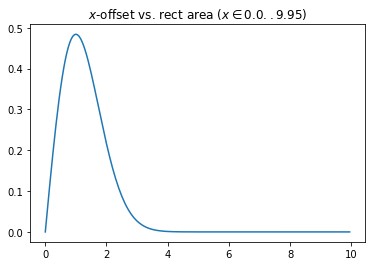

And now the area between 0.5 and 1.5:

```
arange = np.arange(0.5, 1.5, 0.01)
areas = rect_area(arange)
plt.title('$x$-offset vs. rect area ($x \\in {}..{}$)'.format(round(min(arange),5), round(max(arange),5)))
plt.plot(arange, areas)
```

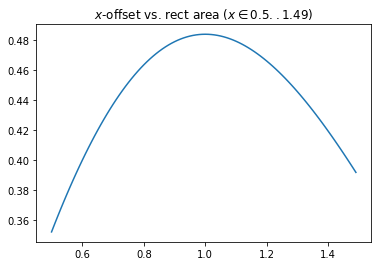

It looks like the optimal $x$is 1.0. We continue to verify:

```
arange = np.arange(0.9, 1.1, 0.001)
areas = rect_area(arange)
plt.title('$x$-offset vs. rect area ($x \\in {}..{}$)'.format(round(min(arange),5), round(max(arange),5)))
plt.plot(arange, areas)
```

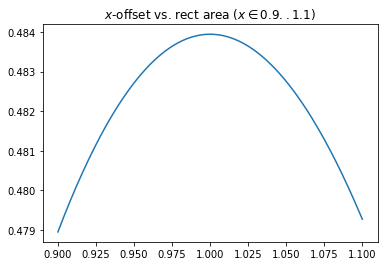

```
arange = np.arange(0.999, 1.001, 0.00001)
areas = rect_area(arange)
plt.title('$x$-offset vs. rect area ($x \\in {}..{}$)'.format(round(min(arange),5), round(max(arange),5)))
plt.plot(arange, areas)
plt.plot([1,1],[0.4839409,0.4839415])
plt.xticks(arange[::25], rotation=20)
plt.gca().get_yaxis().get_major_formatter().set_useOffset(False)
```

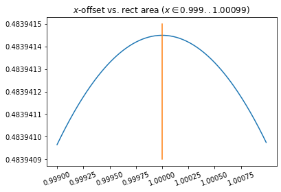

Clearly, the optimal $x$-offset is 1, corresponding to the rectangle spanning between -1 and 1 with a height of normal(1) $\approx 0.24197072451914337$

```
arange = np.arange(-3, 3, 0.05)
plt.title('maximal rectangle inscribed in normal distribution')
plt.plot(arange, normal(arange))
plt.plot([-1, -1, 1, 1], [0, normal(-1), normal(1), 0])
plt.plot([min(arange), max(arange)], [0, 0], color='black')
```

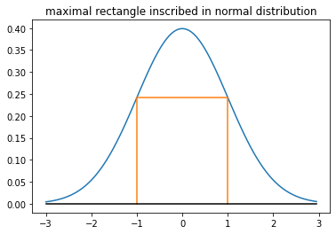